# Part II - Ford GoBike Key Insights

## by (Oluwatofunmi Adedoyin)

## Investigation Overview

In this data set, I tried to investigate various effects on average duration per trip including the relationship between gender and user type

## Dataset Overview

This data set includes information about rides made in a bike-sharing system covering the greater San Francisco Bay area The data consists of 174,952 rides.

## 1. Gender Distribution in the Dataset

The chart below is a bar chart that shows the gender distribution amongst riders in the dataset. There are significantly more men in the data than any other gender type

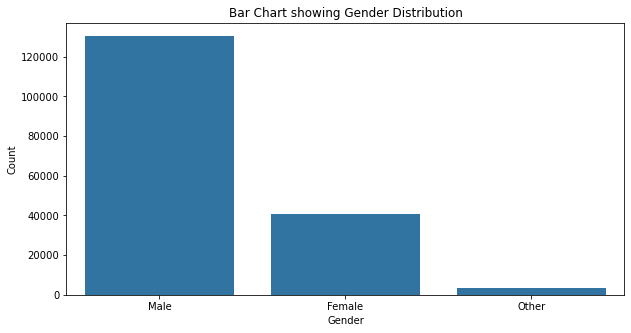

## 2. Average Duration per trip by Gender

The chart below suggests that Men tend to use less time on average per trip.

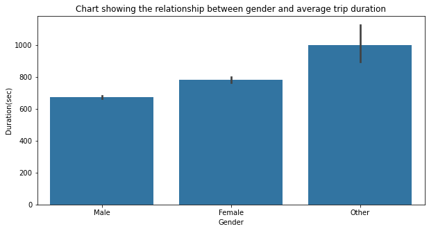

## 3. Average Duration per trip by User Type

The chart below suggests that `Subscribers` tend to use less time per trip compared to `customers`. However more information such as the distance of each trip amongst others would be necessary to draw definitive conclusions.

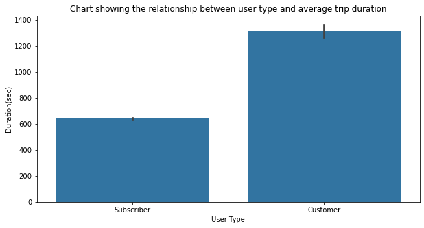

## 4. Distribution of User Types across Gender

The Chart below shows the distribution of user type for each Gender.The chart shows that there are more subscibers than customers for each gender type. Males have more subscribers and customers given that there are more males than any other gender type in this dataset as illustrated earlier.

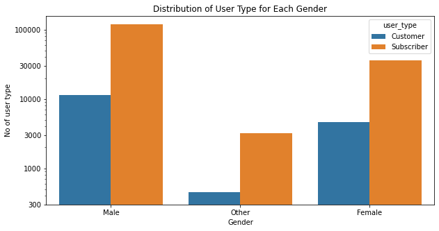

## 5. Rider Station Traffic by Gender

The chart above shows the top 10 start stations distributed by gender. It can be seen that Males generally seem to be the highest contributors to traffic across all stations

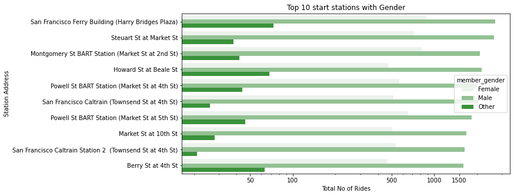

## 6. Top 10 Start stations by rider traffic

There are 329 start stations in this dataset. The chart below highlights the top 10 start stations by the total number of rides. This would be a good metric in selecting stations to place ads, surverys or any other activity that would require engagement with riders

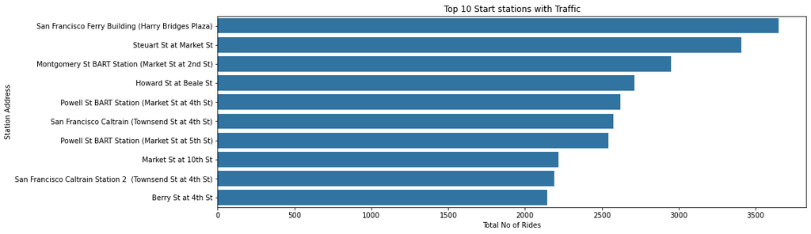